# climate-10-portfolio-01

Matthew J. Menne, Imke Durre, Russell S. Vose, Byron E. Gleason, and Tamara G. Houston, 2012: An Overview of the Global Historical Climatology Network-Daily Database. J. Atmos. Oceanic Technol., 29, 897-910. doi:10.1175/JTECH-D-11-00103.1.

```python
# Import required packages
import pandas as pd
```

> **Your task:**
> 1. Pick an expressive variable name for the URL.
> 2. Reformat the URL so that it adheres to the [79-character PEP-8 line limit](https://peps.python.org/pep-0008/#maximum-line-length). You should see two vertical lines in each cell - don’t let your code go past the second line.
> 3. At the end of the cell where you define your url variable, **call your variable (type out its name)** so it can be tested.

```python
chicago_url = (
    'https://www.ncei.noaa.gov/access/services/data/v1'
    '?dataset=daily-summaries'
    '&dataTypes=TMAX'
    '&stations=USC00111577'
    '&units=standard'
    '&startDate=1929-01-01'
    '&endDate=2023-12-31')
chicago_url
```

```
'https://www.ncei.noaa.gov/access/services/data/v1?dataset=daily-summaries&dataTypes=TMAX&stations=USC00111577&units=standard&startDate=1929-01-01&endDate=2023-12-31'
```

## **Download and get started working with NCEI data**

Just like you did with the practice data, go ahead and use pandas to import data from your API URL into Python. If you didn’t do it already, you should import the pandas library **at the top of this notebook** so that others who want to use your code can find it easily.

```python
# Import data into Python from NCEI API
chicago_climate_df = pd.read_csv(
    chicago_url,
    index_col='DATE',
    parse_dates=True)
```

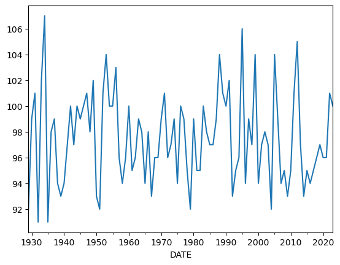

```python
chicago_climate_df.TMAX.resample('YS').max().plot()
```